# PA1_template

Javier Rios Perez

1/14/2017

This is the solution for the Reproducible research - week 2 course.

Loading the necesary libraries

```r
library(ISLR)
library(plyr)
library(dplyr)
```

```r
library(pander)
library(ggplot2)
```

Loading and processing the data

```r
original_data <- read.csv("activity.csv", header = TRUE)
monitoring_data <- original_data
```

Converting the data column into a date variable

```r
monitoring_data$date <- as.character(monitoring_data$date)
monitoring_data$date <- as.Date(monitoring_data$date, format = "%Y-%m-%d")
```

# What is mean total number of steps taken per day?

1. Calculate the total number of steps taken per day

```r
total_num_steps <- as.data.frame(ddply(monitoring_data,~date,summarise,
                                       sum=sum(steps, na.rm = TRUE)))
head(total_num_steps)
```

```
##         date   sum
## 1 2012-10-01     0
## 2 2012-10-02   126
## 3 2012-10-03 11352
## 4 2012-10-04 12116
## 5 2012-10-05 13294
## 6 2012-10-06 15420
```

2. If you do not understand the difference between a histogram and a barplot, research the difference between them. Make a histogram of the total number of steps taken each day

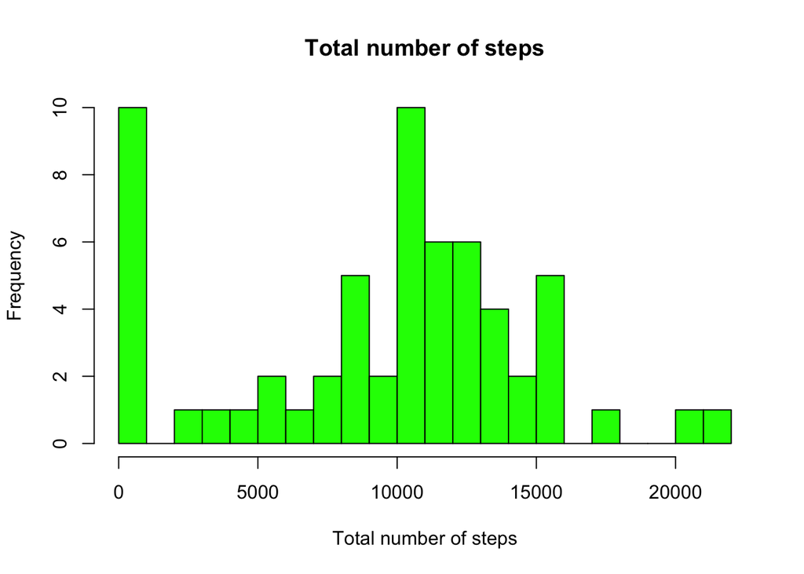

```r
hist(total_num_steps$sum, breaks = 20, col = "green", main = "Total number of steps",
     xlab = "Total number of steps")
```

```r
org_steps_per_day <- ddply(monitoring_data,~date,summarise,org_sum=sum(steps))
mean_median_original <- ddply(monitoring_data,~date,summarise,mean=mean(steps),
                              median=median(steps))

head(mean_median_original)
```

```
##         date     mean median
## 1 2012-10-01       NA     NA
## 2 2012-10-02  0.43750      0
## 3 2012-10-03 39.41667      0
## 4 2012-10-04 42.06944      0
## 5 2012-10-05 46.15972      0
## 6 2012-10-06 53.54167      0
```

```r
tail(mean_median_original)
```

```
##          date     mean median
## 56 2012-11-25 41.09028      0
## 57 2012-11-26 38.75694      0
## 58 2012-11-27 47.38194      0
## 59 2012-11-28 35.35764      0
## 60 2012-11-29 24.46875      0
## 61 2012-11-30       NA     NA
```

# What is the average daily activity pattern?

1. Make a time series plot (i.e. type = “l”) of the 5-minute interval (x-axis) and the average number of steps taken, averaged across all days (y-axis)

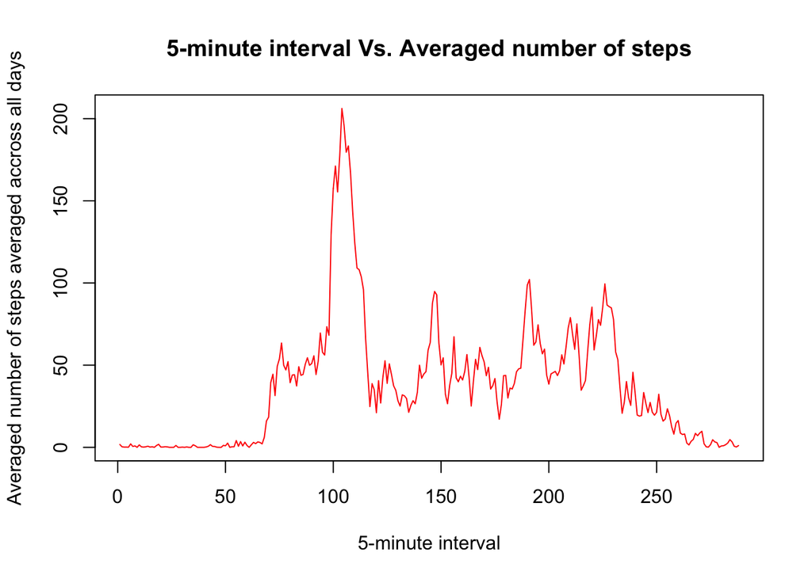

```r
org_num_steps_intervals <- data.frame()
org_num_intervals <- length(unique(monitoring_data$interval))

for(i in 1:org_num_intervals)
{
  org_steps_interval <- filter(monitoring_data, interval == monitoring_data$interval[i])
  org_num_steps_intervals[i,1] <- mean(org_steps_interval$steps, na.rm = TRUE)
  org_num_steps_intervals[i,2] <- org_steps_interval$interval[1]
}


plot(org_num_steps_intervals[,1], type = "l", col = "red", xlab = "5-minute interval",
     ylab = "Averaged number of steps averaged accross all days",
     main = "5-minute interval Vs. Averaged number of steps")
```

2. Which 5-minute interval, on average across all the days in the dataset, contains the maximum number of steps?

```r
org_max <- max(org_num_steps_intervals[,1])
org_max_interval_aux <- which(org_num_steps_intervals[,1] == org_max)
org_num_steps_intervals[org_max_interval_aux,2]
```

```
## [1] 835
```

# Imputing missing values

1. Calculate and report the total number of missing values in the dataset (i.e. the total number of rows with NAs)

```r
total_NA <- is.na(monitoring_data$steps)
table(total_NA)
```

```
## total_NA
## FALSE  TRUE
## 15264  2304
```

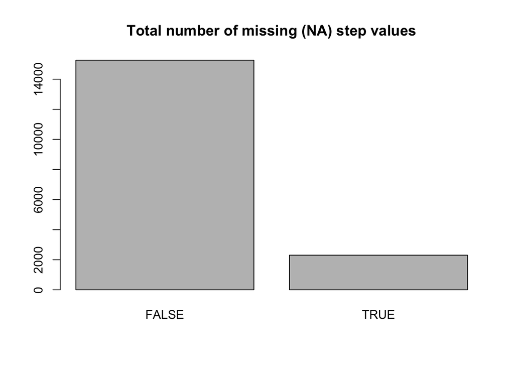

```r
barplot(table(total_NA), main = "Total number of missing (NA) step values")
```

2. Devise a strategy for filling in all of the missing values in the dataset. The strategy does not need to be sophisticated. For example, you could use the mean/median for that day, or the mean for that 5-minute interval, etc.

```r
aux <- unique(monitoring_data$date)
monitoring_clean <- data.frame()

for(i in 1: length(aux))

{
  day <- monitoring_data[monitoring_data$date == unique(monitoring_data$date)[i],]
  if(any(is.na(day)))
  {
    temp <- mean(day$steps, na.rm = TRUE)
    if(is.nan(temp))
    {
      temp <- 0
    }

  }
  # here i need to replace the NA <- temp for each day, remember to change and seve
  # the results in a data frame
  for(j in 1:dim(day)[1])
  {
    if(is.na(day[j,1]))
    {
      day[j,1] <- temp
    }
  }
  monitoring_clean <- rbind(monitoring_clean,day)
}

head(monitoring_clean)
```

```
##   steps       date interval
## 1     0 2012-10-01        0
## 2     0 2012-10-01        5
## 3     0 2012-10-01       10
## 4     0 2012-10-01       15
## 5     0 2012-10-01       20
## 6     0 2012-10-01       25
```

3. Create a new dataset that is equal to the original dataset but with the missing data filled in.

```r
head(monitoring_clean)
```

```
##   steps       date interval
## 1     0 2012-10-01        0
## 2     0 2012-10-01        5
## 3     0 2012-10-01       10
## 4     0 2012-10-01       15
## 5     0 2012-10-01       20
## 6     0 2012-10-01       25
```

```r
tail(monitoring_clean)
```

```
##       steps       date interval
## 17563     0 2012-11-30     2330
## 17564     0 2012-11-30     2335
## 17565     0 2012-11-30     2340
## 17566     0 2012-11-30     2345
## 17567     0 2012-11-30     2350
## 17568     0 2012-11-30     2355
```

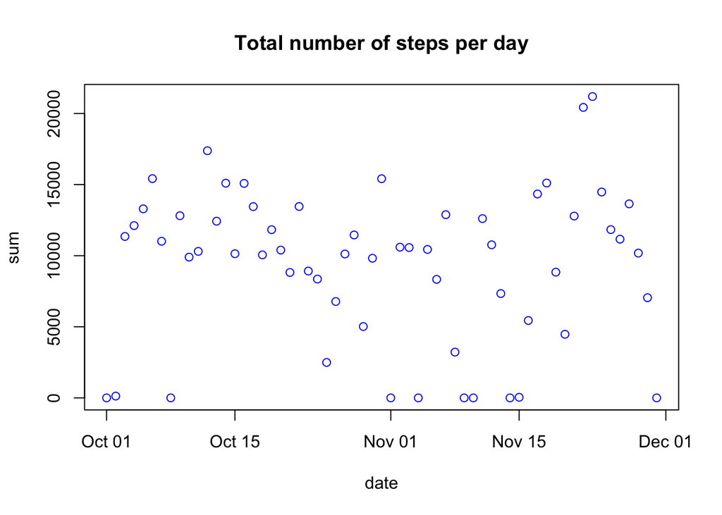

```r
steps_per_day <- ddply(monitoring_clean,~date,summarise,sum=sum(steps))
plot(steps_per_day, main = "Total number of steps per day", col = "blue")
```

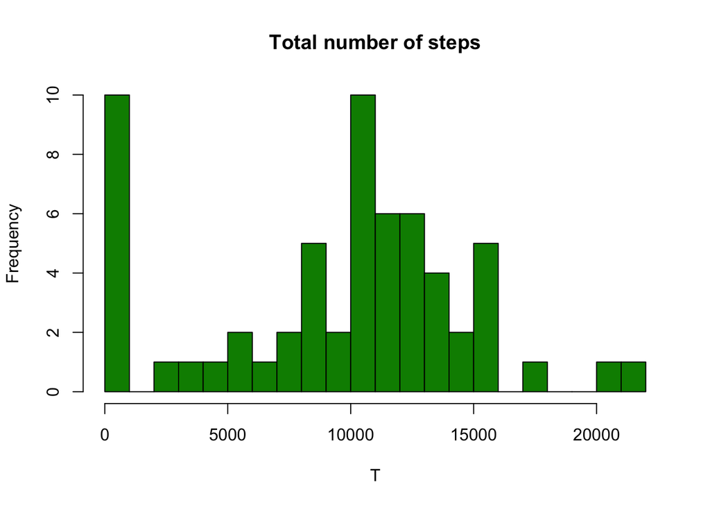

```r
# plotting the histogram

hist(steps_per_day$sum, breaks = 20, col = "green4", main = "Total number of steps",
     xlab = "T")
```

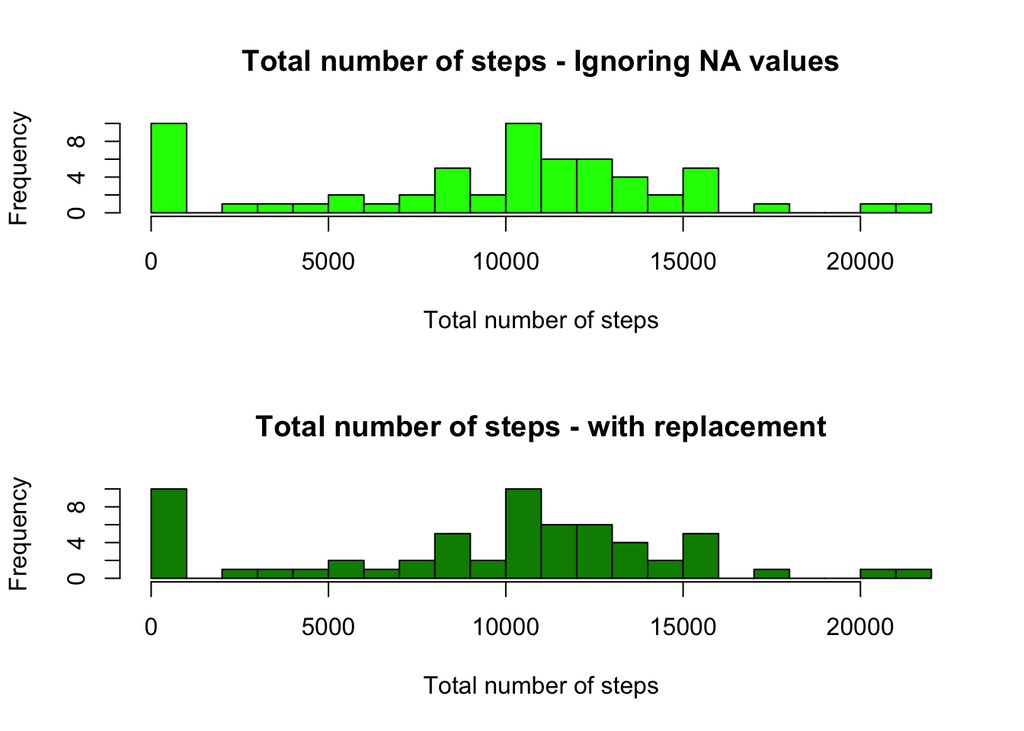

```r
par(mfrow = c(2,1))
hist(total_num_steps$sum, breaks = 20, col = "green", main = "Total number of steps - Ignoring NA values",
     xlab = "Total number of steps")
hist(steps_per_day$sum, breaks = 20, col = "green4", main = "Total number of steps - with replacement",
     xlab = "Total number of steps")
```

```r
# Calculate and report the mean and median of the total number of steps taken per day

mean_median_with_substitution <- ddply(monitoring_clean,
                                       ~date,summarise,mean_sub=mean(steps),median_sub=median(steps))

# making a new data frame that does not contain missing values
mean_median_combined <- cbind(mean_median_original,
                              mean_median_with_substitution$mean_sub, mean_median_with_substitution$median_sub)

# comparing the total number of steps

total_number_steps_combined <- cbind(org_steps_per_day, steps_per_day[,2])

non_zeros <- monitoring_clean[-which(monitoring_clean$steps == 0),]
daily_non_zeros <- ddply(non_zeros,~date,summarise,sum=sum(steps))
plot(daily_non_zeros, main = "Total number of steps per day")
dev.off()
```

[output not shown]

# Are there differences in activity patterns between weekdays and weekends?

1. Create a new factor variable in the dataset with two levels – “weekday” and “weekend” indicating whether a given date is a weekday or weekend day.

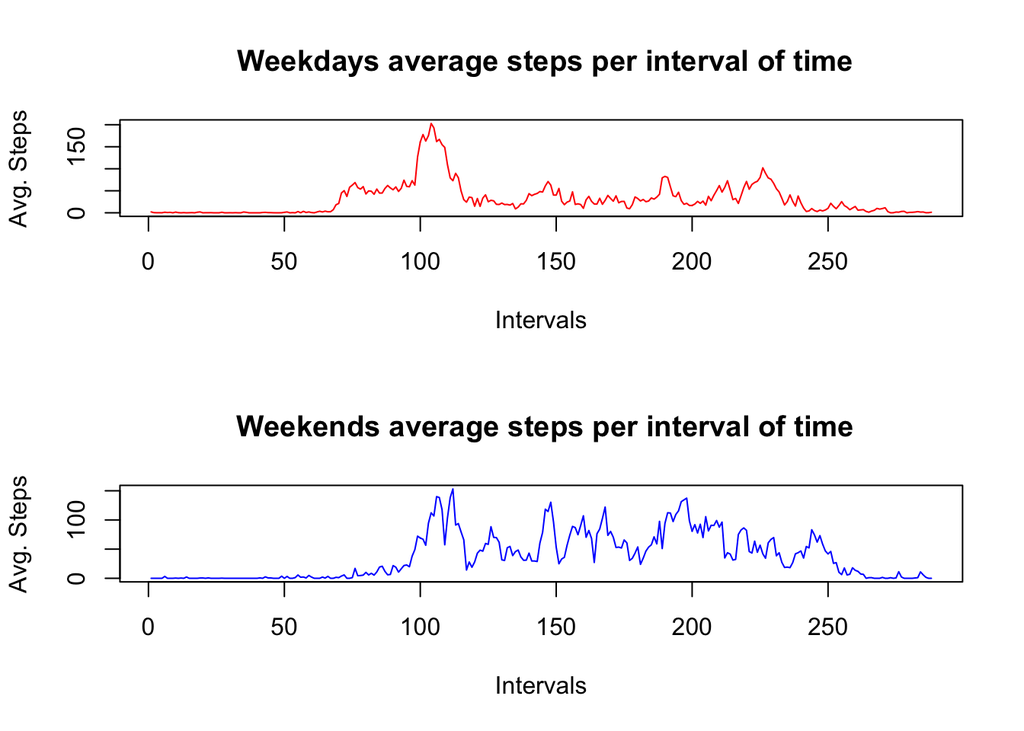

```r
weekdays <- data.frame() # i am going to store the resutls of weekend/weekend analysis

for(i in 1:length(monitoring_clean$date))

{
  if(weekdays(monitoring_clean[i,2]) == "Saturday" | weekdays(monitoring_clean[i,2]) == "Sunday")
  {
    temp <- "weekend"
  }

  else
  {
    temp <- "weekday"
  }

  weekdays[i,1] <- temp
  i <- i+1
}

weekly_steps_per_day <- as.data.frame(cbind(monitoring_clean, weekdays))
colnames(weekly_steps_per_day)[4] <- "weekdays"
weekly_steps_per_day$weekdays <- as.factor(weekly_steps_per_day$weekday)


num_steps_intervals_weekdays <- data.frame()
avg_steps_intervals_weekdays <- data.frame()

num_steps_intervals_weekends <- data.frame()
avg_steps_intervals_weekends <- data.frame()

num_intervals_weekdays <- length(unique(weekly_steps_per_day$interval))

weekdays_data <- filter(weekly_steps_per_day, weekly_steps_per_day$weekdays == "weekday")
weekends_data <-  filter(weekly_steps_per_day, weekly_steps_per_day$weekdays == "weekend")

for(i in 1:num_intervals_weekdays)
{
  num_steps_intervals_weekdays <- filter(weekdays_data, interval == weekdays_data$interval[i])
  avg_steps_intervals_weekdays[i,1] <- mean(num_steps_intervals_weekdays$steps)
  avg_steps_intervals_weekdays[i,2] <- num_steps_intervals_weekdays$interval[2]
  avg_steps_intervals_weekdays[i,3] <- num_steps_intervals_weekdays$weekdays[4]
}

for(i in 1:num_intervals_weekdays)
{
  num_steps_intervals_weekends <- filter(weekends_data, interval == weekends_data$interval[i])
  avg_steps_intervals_weekends[i,1] <- mean(num_steps_intervals_weekends$steps)
  avg_steps_intervals_weekends[i,2] <- num_steps_intervals_weekends$interval[2]
  avg_steps_intervals_weekends[i,3] <- num_steps_intervals_weekends$weekdays[4]
}

# changing col names for both weekdays and weekend new dataframes

colnames(avg_steps_intervals_weekdays) <- c("avg", "intervals", "weekday")
colnames(avg_steps_intervals_weekends) <- c("avg", "intervals", "weekday")

# plotting the results
par(mfrow = c(2,1))
plot(avg_steps_intervals_weekdays$avg, type = "l", col = "red", xlab = "Intervals", ylab = "Avg. Steps",
     main = " Weekdays average steps per interval of time")
plot(avg_steps_intervals_weekends$avg, type = "l", col = "blue", xlab = "Intervals", ylab = "Avg. Steps",
     main = " Weekends average steps per interval of time")
```

```r
dev.off()
```